# tpcr7

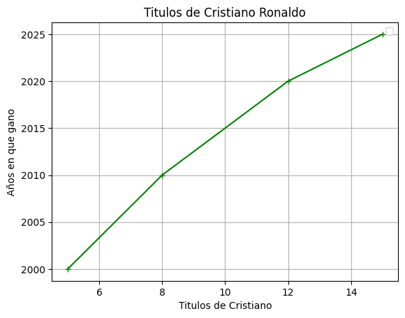

```python
import matplotlib.pyplot as plt
plt.title("Titulos de Cristiano Ronaldo")
plt.xlabel("Titulos de Cristiano")
plt.ylabel("Años en que gano")
plt.grid(True)
plt.legend(['Data Series'])
plt.plot([5,8,12,15], [2000,2010,2020,2025], 'g-+')
```

#### Títulos de Cristiano Ronaldo a lo largo del tiempo

Este gráfico de líneas muestra la cantidad de títulos que Cristiano Ronaldo ganó en diferentes años.  
Se eligió este tipo de visualización porque permite ver la progresión y el ritmo de sus logros a lo largo del tiempo.

# Títulos de Cristiano Ronaldo por club

```
<BarContainer object of 5 artists>
```

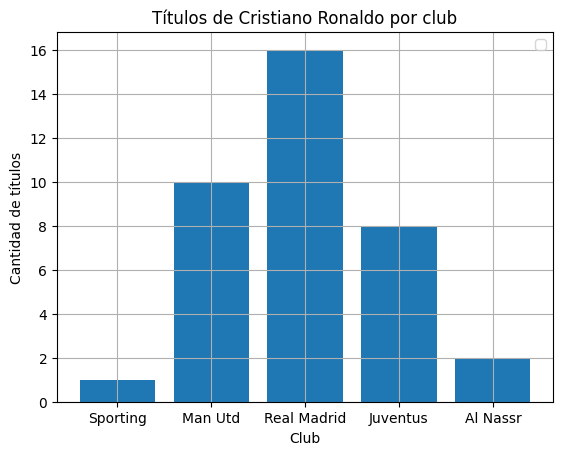

```python
import matplotlib.pyplot as plt
plt.title("Títulos de Cristiano Ronaldo por club")
plt.xlabel("Club")
plt.ylabel("Cantidad de títulos")
plt.grid(True)
plt.legend(['Data Series'])
plt.bar(['Sporting', 'Man Utd', 'Real Madrid', 'Juventus', 'Al Nassr'], [1, 10, 16, 8, 2])
```

#### Títulos de Cristiano Ronaldo por club

Este gráfico de barras muestra la cantidad de títulos ganados por Cristiano Ronaldo en cada uno de los clubes donde jugó.  
Se utilizó un gráfico de barras porque es ideal para comparar cantidades entre diferentes categorías.  
La altura de cada barra representa cuántos títulos obtuvo en ese equipo, lo que permite ver claramente dónde tuvo más éxito.

# Relación entre edad y goles por temporada

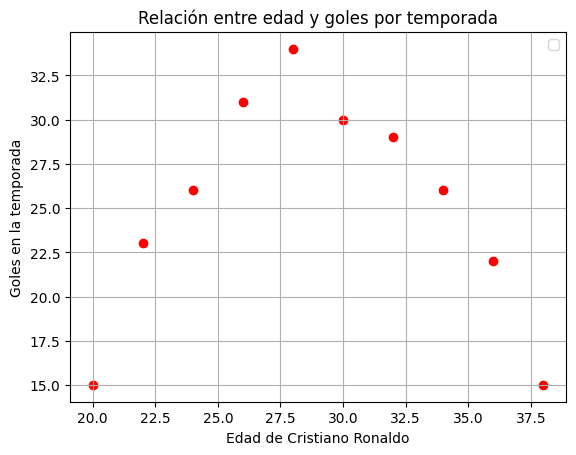

```python
import matplotlib.pyplot as plt
edades = [20, 22, 24, 26, 28, 30, 32, 34, 36, 38]
goles = [15, 23, 26, 31, 34, 30, 29, 26, 22, 15]
plt.title("Relación entre edad y goles por temporada")
plt.xlabel("Edad de Cristiano Ronaldo")
plt.ylabel("Goles en la temporada")
plt.grid(True)
plt.legend(['Goles por edad'])
plt.scatter(edades, goles, color='red')
```

#### Relación entre edad y goles por temporada

Este gráfico de dispersión muestra la relación entre la edad de Cristiano Ronaldo y la cantidad de goles que marcó en cada temporada.  
Se eligió un scatter plot porque es útil para observar cómo una variable (edad) afecta a otra (goles).  
En este caso, se puede ver que el rendimiento goleador alcanza un pico alrededor de los 28 años, y luego comienza a disminuir.

# Goles y asistencias por temporada con anotaciones

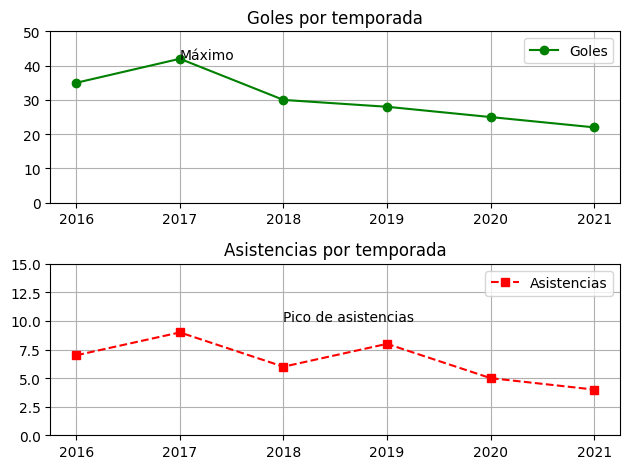

```python
import matplotlib.pyplot as plt

x = ['2016', '2017', '2018', '2019', '2020', '2021']
goles = [35, 42, 30, 28, 25, 22]
asistencias = [7, 9, 6, 8, 5, 4]

fig, axs = plt.subplots(2, 1)

axs[0].plot(x, goles, 'g-o', label='Goles')
axs[0].set_title("Goles por temporada")
axs[0].set_ylim(0, 50)
axs[0].text(1, 42, "Máximo")
axs[0].legend()
axs[0].grid(True)

axs[1].plot(x, asistencias, 'r--s', label='Asistencias')
axs[1].set_title("Asistencias por temporada")
axs[1].set_ylim(0, 15)
axs[1].text(2, 10, "Pico de asistencias")
axs[1].legend()
axs[1].grid(True)

plt.tight_layout()
plt.show()
```

#### Goles y asistencias por temporada con anotaciones

# Distribución de títulos de Cristiano Ronaldo por club

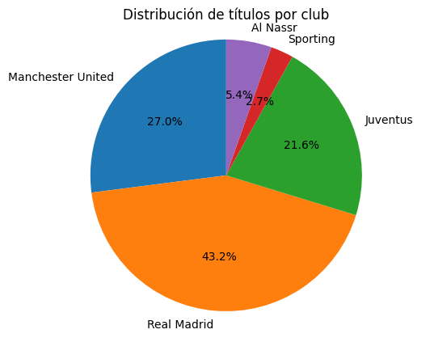

```python
import matplotlib.pyplot as plt

# Datos ficticios: títulos por club
labels = ['Manchester United', 'Real Madrid', 'Juventus', 'Sporting', 'Al Nassr']
titulos = [10, 16, 8, 1, 2]

plt.title("Distribución de títulos por club")
plt.pie(titulos, labels=labels, autopct='%1.1f%%', startangle=90)
plt.axis('equal')  # Mantener forma circular
plt.show()
```

#### Distribución de títulos de Cristiano Ronaldo por club

Este gráfico de torta representa el porcentaje de títulos que Cristiano Ronaldo ha ganado en cada club a lo largo de su carrera.  
Se eligió este tipo de gráfico porque es ideal para visualizar cómo se distribuye un total entre varias categorías.  
Real Madrid representa la mayor porción, lo que resalta su etapa más exitosa en cuanto a títulos.